# TA notes for OVR-OVO Usage of Sklearn SVM Interface

*Xudong Wang 王旭东*

*xudongwang@link.cuhk.edu.cn*

*School of Data Science*

*The Chinese University of Hongkong, Shenzhen*

*2022.10.26*

## Summary and Remarks

By checking the source code from sikit-learn and libsvm, we find that actually, the decision_function_shape='ovr' don't take effect in the SVC() interface. Actually, no matter how u set, the SVC() only works as ovo since the source code is libsvm-svm.cpp. https://github.com/scikit-learn/scikit-learn/blob/main/sklearn/svm/src/libsvm/svm.cpp

Hence, the only way we really using OVR in sklearn interface is that, first, we make a one-hot encoding(Directly input y like[0, 1, 2, ...] also ok) for reshape the target/Y data. Then, using the OneVsRestClassifier() interface, you can regard that the OVR(SVC(#the decision_function_shape still take no effect.#)) actually trained 3 SVC-ovo for binary classification (Please also note that for binary classification, ovo is definitely same to ovr).

From Prof Wu and Prof Fan: Both OvO/OvR are acceptable to finish this assignment. Students using any methods are ok(Even they actually do not notice the hyper parameters "decision_function_shape", but the basic idea for multiclass classification(OvO/OvR) is very important). Here the scikit-learn API has these unfixed bugs. Hope this .ipynb and some tests from TA can help address their confusion.

```python
import numpy as np
import sklearn
import sklearn.datasets as dataset
from sklearn.svm import SVC
from sklearn.decomposition import PCA
from sklearn.multiclass import OneVsRestClassifier
import matplotlib.pyplot as plt
%matplotlib inline
```

```python
np.random.seed(0)
print(sklearn.__version__)
data = dataset.load_iris().data
target = dataset.load_iris().target
```

```
0.24.1
```

## Check the Scikit-learn SVC interface (Unfixed bugs for hyperparam "decision_function_shape" )

```python
model_1 = SVC(kernel='linear',C=100,random_state=0,decision_function_shape='ovr')
model_1.fit(data,target)
print(model_1.coef_)
```

```
[[-4.62585381e-02  5.21182800e-01 -1.00304462e+00 -4.64129785e-01]
 [-7.22312566e-03  1.78941210e-01 -5.38364588e-01 -2.92392628e-01]
 [ 1.84518712e+00  3.25919270e+00 -4.67069616e+00 -1.08654150e+01]]
```

```python
model_1 = SVC(kernel='linear',C=100,random_state=0,decision_function_shape='ovo')
model_1.fit(data,target)
print(model_1.coef_)
```

```
[[-4.62585381e-02  5.21182800e-01 -1.00304462e+00 -4.64129785e-01]
 [-7.22312566e-03  1.78941210e-01 -5.38364588e-01 -2.92392628e-01]
 [ 1.84518712e+00  3.25919270e+00 -4.67069616e+00 -1.08654150e+01]]
```

## Check the Scikit-learn OVR interface

```python
model_2 = OneVsRestClassifier(SVC(kernel='linear',C=100,random_state=0))
model_2.fit(data,target)
print(model_2.coef_)
```

```
[[-0.04575352  0.52216766 -1.00294058 -0.46406882]
 [-0.10021179 -2.26571458  1.25100982 -2.79502315]
 [-1.84493158 -3.25976453  4.67015877 10.86509564]]
```

```python
model_2.estimators_[0].coef_
```

```
array([[-0.04575352,  0.52216766, -1.00294058, -0.46406882]])
```

```python
model_2.estimators_[1].coef_
```

```
array([[-0.10021179, -2.26571458,  1.25100982, -2.79502315]])
```

```python
model_2.estimators_[2].coef_
```

```
array([[-1.84493158, -3.25976453,  4.67015877, 10.86509564]])
```

```python
model_3 = OneVsRestClassifier(SVC(kernel='linear',C=100,random_state=0,decision_function_shape='ovo'))
model_3.fit(data,target)
print(model_3.coef_)
```

```
[[-0.04575352  0.52216766 -1.00294058 -0.46406882]
 [-0.10021179 -2.26571458  1.25100982 -2.79502315]
 [-1.84493158 -3.25976453  4.67015877 10.86509564]]
```

```python
model_4 = OneVsRestClassifier(SVC(kernel='linear',C=100,random_state=0,decision_function_shape='ovr'))
model_4.fit(data,target)
print(model_4.coef_)
```

```
[[-0.04575352  0.52216766 -1.00294058 -0.46406882]
 [-0.10021179 -2.26571458  1.25100982 -2.79502315]
 [-1.84493158 -3.25976453  4.67015877 10.86509564]]
```

## Visualization to Compare the OvO and OvR boundies in PCA-transformed 2D Iris

Here, first using the PCA to reduce the data dimension from 4 to 2 and then using SVM on the 2D transformed data and visualization the decision bound on it~

```python
def plot_hyperplane(clf, min_x, max_x, linestyle, label, decision_function_shape='ovr', class_ = None):

    if decision_function_shape=='ovr':
        # get the separating hyperplane
        w = clf.coef_[0]
        a = -w[0] / w[1]
        xx = np.linspace(min_x - 5, max_x + 5)  # make sure the line is long enough
        yy = a * xx - (clf.intercept_[0]) / w[1]
        plt.plot(xx, yy, linestyle, label=label)

    if decision_function_shape=='ovo':
        w = clf.coef_[class_]
        a = -w[0] / w[1]
        xx = np.linspace(min_x - 5, max_x + 5)  # make sure the line is long enough
        yy = a * xx - (clf.intercept_[class_]) / w[1]
        plt.plot(xx, yy, linestyle, label=label)


def plot_subfigure(X, Y, subplot, title, decision_function_shape='ovr'):

    transform = "pca"
    X = PCA(n_components=2,random_state = 0).fit_transform(X)

    min_x = np.min(X[:, 0])
    max_x = np.max(X[:, 0])
    min_y = np.min(X[:, 1])
    max_y = np.max(X[:, 1])

    if decision_function_shape=='ovr':
        classif = OneVsRestClassifier(SVC(kernel="linear", random_state=0,decision_function_shape='ovr'))
        classif.fit(X, Y)
    if decision_function_shape=='ovo':
        classif = SVC(kernel="linear", random_state=0,decision_function_shape='ovo')
        classif.fit(X, Y)

    plt.subplot(1, 2, subplot)
    plt.title(title)


    zero_class = np.where(Y==0)
    one_class = np.where(Y==1)
    two_class = np.where(Y==2)

    plt.scatter(X[:, 0], X[:, 1], s=40, c="gray", edgecolors=(0, 0, 0))
    plt.scatter(
        X[zero_class, 0],
        X[zero_class, 1],
        s=160,
        edgecolors="b",
        facecolors="none",
        linewidths=2,
        label="Class 1",
    )
    plt.scatter(
        X[one_class, 0],
        X[one_class, 1],
        s=80,
        edgecolors="orange",
        facecolors="none",
        linewidths=2,
        label="Class 2",
    )
    plt.scatter(
        X[two_class, 0],
        X[two_class, 1],
        s=80,
        edgecolors="red",
        facecolors="none",
        linewidths=2,
        label="Class 3",
    )

    if decision_function_shape=='ovr':
        plot_hyperplane(
            classif.estimators_[0], min_x, max_x, "k--", "Boundary\nfor class 1"
        )
        plot_hyperplane(
            classif.estimators_[1], min_x, max_x, "k-.", "Boundary\nfor class 2"
        )
        plot_hyperplane(
            classif.estimators_[2], min_x, max_x, "k-*", "Boundary\nfor class 3"
        )
    if decision_function_shape=='ovo':
        plot_hyperplane(
            classif, min_x, max_x, "k--", "Boundary\nfor class 1",decision_function_shape='ovo',class_ = 0
        )
        plot_hyperplane(
            classif, min_x, max_x, "k-.", "Boundary\nfor class 2",decision_function_shape='ovo',class_ = 1
        )
        plot_hyperplane(
            classif, min_x, max_x, "k-*", "Boundary\nfor class 3",decision_function_shape='ovo',class_ = 2
        )
    plt.xticks(())
    plt.yticks(())

    plt.xlim(min_x - 0.5 * max_x, max_x + 0.5 * max_x)
    plt.ylim(min_y - 0.5 * max_y, max_y + 0.5 * max_y)

    plt.xlabel("First principal component")
    plt.ylabel("Second principal component")
    plt.legend(loc="upper left")
```

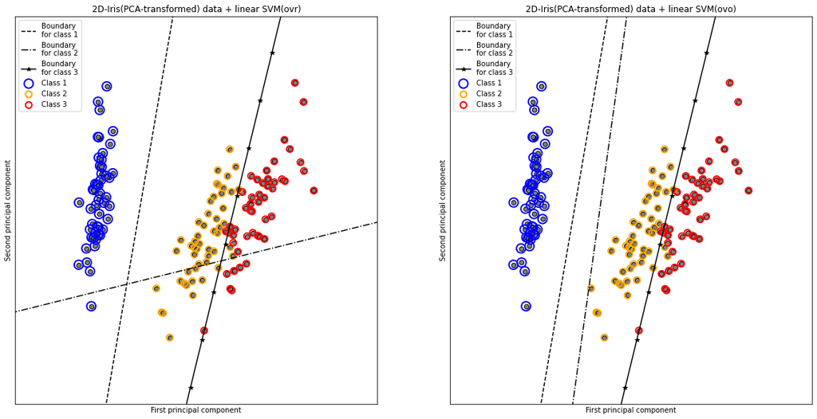

```python
plt.figure(figsize=(20, 10))

X, Y = data, target

decision_function_shape='ovr'
plot_subfigure(X, Y, 1, f"2D-Iris(PCA-transformed) data + linear SVM({decision_function_shape})", decision_function_shape='ovr')



decision_function_shape='ovo'
plot_subfigure(X, Y, 2, f"2D-Iris(PCA-transformed) data + linear SVM({decision_function_shape})", decision_function_shape='ovo')
```

Please note that here we perform the SVM on 2D data. From more, you can refer the https://scikit-learn.org/stable/auto_examples/miscellaneous/plot_multilabel.html#sphx-glr-auto-examples-miscellaneous-plot-multilabel-py